# Risk Factor Analysis

## Outcome Variable

**Outcome Variable:** wast_rec90d

## Predictor Variables

**Intervention Variable:** gagebrth

**Adjustment Set:**

unadjusted

## Stratifying Variables

The analysis was stratified on these variable(s):

- agecat
- studyid
- country

## Data Summary

| agecat | studyid | country | gagebrth | wast_rec90d | n_cell | n |
| --- | --- | --- | --- | --- | --- | --- |
| 0-24 months | ki1000108-CMC-V-BCS-2002 | INDIA | Full or late term | 0 | 68 | 299 |
| 0-24 months | ki1000108-CMC-V-BCS-2002 | INDIA | Full or late term | 1 | 117 | 299 |
| 0-24 months | ki1000108-CMC-V-BCS-2002 | INDIA | Preterm | 0 | 21 | 299 |
| 0-24 months | ki1000108-CMC-V-BCS-2002 | INDIA | Preterm | 1 | 28 | 299 |
| 0-24 months | ki1000108-CMC-V-BCS-2002 | INDIA | Early term | 0 | 21 | 299 |
| 0-24 months | ki1000108-CMC-V-BCS-2002 | INDIA | Early term | 1 | 44 | 299 |
| 0-24 months | ki1000108-IRC | INDIA | Full or late term | 0 | 92 | 382 |
| 0-24 months | ki1000108-IRC | INDIA | Full or late term | 1 | 134 | 382 |
| 0-24 months | ki1000108-IRC | INDIA | Preterm | 0 | 24 | 382 |
| 0-24 months | ki1000108-IRC | INDIA | Preterm | 1 | 29 | 382 |
| 0-24 months | ki1000108-IRC | INDIA | Early term | 0 | 39 | 382 |
| 0-24 months | ki1000108-IRC | INDIA | Early term | 1 | 64 | 382 |
| 0-24 months | ki1000109-EE | PAKISTAN | Full or late term | 0 | 5 | 323 |
| 0-24 months | ki1000109-EE | PAKISTAN | Full or late term | 1 | 1 | 323 |
| 0-24 months | ki1000109-EE | PAKISTAN | Preterm | 0 | 134 | 323 |
| 0-24 months | ki1000109-EE | PAKISTAN | Preterm | 1 | 143 | 323 |
| 0-24 months | ki1000109-EE | PAKISTAN | Early term | 0 | 21 | 323 |
| 0-24 months | ki1000109-EE | PAKISTAN | Early term | 1 | 19 | 323 |
| 0-24 months | ki1017093c-NIH-Crypto | BANGLADESH | Full or late term | 0 | 16 | 310 |
| 0-24 months | ki1017093c-NIH-Crypto | BANGLADESH | Full or late term | 1 | 25 | 310 |
| 0-24 months | ki1017093c-NIH-Crypto | BANGLADESH | Preterm | 0 | 57 | 310 |
| 0-24 months | ki1017093c-NIH-Crypto | BANGLADESH | Preterm | 1 | 92 | 310 |
| 0-24 months | ki1017093c-NIH-Crypto | BANGLADESH | Early term | 0 | 44 | 310 |
| 0-24 months | ki1017093c-NIH-Crypto | BANGLADESH | Early term | 1 | 76 | 310 |
| 0-24 months | ki1066203-TanzaniaChild2 | TANZANIA, UNITED REPUBLIC OF | Full or late term | 0 | 128 | 666 |
| 0-24 months | ki1066203-TanzaniaChild2 | TANZANIA, UNITED REPUBLIC OF | Full or late term | 1 | 247 | 666 |
| 0-24 months | ki1066203-TanzaniaChild2 | TANZANIA, UNITED REPUBLIC OF | Preterm | 0 | 52 | 666 |
| 0-24 months | ki1066203-TanzaniaChild2 | TANZANIA, UNITED REPUBLIC OF | Preterm | 1 | 77 | 666 |
| 0-24 months | ki1066203-TanzaniaChild2 | TANZANIA, UNITED REPUBLIC OF | Early term | 0 | 67 | 666 |
| 0-24 months | ki1066203-TanzaniaChild2 | TANZANIA, UNITED REPUBLIC OF | Early term | 1 | 95 | 666 |

[output cut: 168 more lines]

The following strata were considered:

- agecat: 0-24 months, studyid: ki1000108-CMC-V-BCS-2002, country: INDIA
- agecat: 0-24 months, studyid: ki1000108-IRC, country: INDIA
- agecat: 0-24 months, studyid: ki1000109-EE, country: PAKISTAN
- agecat: 0-24 months, studyid: ki1017093c-NIH-Crypto, country: BANGLADESH
- agecat: 0-24 months, studyid: ki1066203-TanzaniaChild2, country: TANZANIA, UNITED REPUBLIC OF
- agecat: 0-24 months, studyid: ki1101329-Keneba, country: GAMBIA
- agecat: 0-24 months, studyid: ki1119695-PROBIT, country: BELARUS
- agecat: 0-24 months, studyid: ki1135781-COHORTS, country: GUATEMALA
- agecat: 0-24 months, studyid: ki1135781-COHORTS, country: INDIA
- agecat: 0-24 months, studyid: ki1135781-COHORTS, country: PHILIPPINES
- agecat: 0-24 months, studyid: kiGH5241-JiVitA-3, country: BANGLADESH
- agecat: 0-6 months, studyid: ki1000108-CMC-V-BCS-2002, country: INDIA
- agecat: 0-6 months, studyid: ki1000108-IRC, country: INDIA
- agecat: 0-6 months, studyid: ki1000109-EE, country: PAKISTAN
- agecat: 0-6 months, studyid: ki1017093c-NIH-Crypto, country: BANGLADESH
- agecat: 0-6 months, studyid: ki1066203-TanzaniaChild2, country: TANZANIA, UNITED REPUBLIC OF
- agecat: 0-6 months, studyid: ki1101329-Keneba, country: GAMBIA
- agecat: 0-6 months, studyid: ki1119695-PROBIT, country: BELARUS
- agecat: 0-6 months, studyid: ki1135781-COHORTS, country: GUATEMALA
- agecat: 0-6 months, studyid: ki1135781-COHORTS, country: INDIA
- agecat: 0-6 months, studyid: ki1135781-COHORTS, country: PHILIPPINES
- agecat: 0-6 months, studyid: kiGH5241-JiVitA-3, country: BANGLADESH
- agecat: 6-24 months, studyid: ki1000108-CMC-V-BCS-2002, country: INDIA
- agecat: 6-24 months, studyid: ki1000108-IRC, country: INDIA
- agecat: 6-24 months, studyid: ki1000109-EE, country: PAKISTAN
- agecat: 6-24 months, studyid: ki1017093c-NIH-Crypto, country: BANGLADESH
- agecat: 6-24 months, studyid: ki1066203-TanzaniaChild2, country: TANZANIA, UNITED REPUBLIC OF
- agecat: 6-24 months, studyid: ki1101329-Keneba, country: GAMBIA
- agecat: 6-24 months, studyid: ki1119695-PROBIT, country: BELARUS
- agecat: 6-24 months, studyid: ki1135781-COHORTS, country: GUATEMALA
- agecat: 6-24 months, studyid: ki1135781-COHORTS, country: INDIA
- agecat: 6-24 months, studyid: ki1135781-COHORTS, country: PHILIPPINES
- agecat: 6-24 months, studyid: kiGH5241-JiVitA-3, country: BANGLADESH

### Dropped Strata

Some strata were dropped due to rare outcomes:

- agecat: 0-24 months, studyid: ki1000109-EE, country: PAKISTAN
- agecat: 0-6 months, studyid: ki1000109-EE, country: PAKISTAN
- agecat: 0-6 months, studyid: ki1017093c-NIH-Crypto, country: BANGLADESH
- agecat: 6-24 months, studyid: ki1000109-EE, country: PAKISTAN
- agecat: 6-24 months, studyid: ki1017093c-NIH-Crypto, country: BANGLADESH
- agecat: 6-24 months, studyid: ki1119695-PROBIT, country: BELARUS
- agecat: 6-24 months, studyid: ki1135781-COHORTS, country: GUATEMALA
- agecat: 6-24 months, studyid: ki1135781-COHORTS, country: INDIA
- agecat: 6-24 months, studyid: kiGH5241-JiVitA-3, country: BANGLADESH

## Methods Detail

We’re interested in the causal parameters $E[Y_a]$ for all values of $a \in \mathcal{A}$. These parameters represent the mean outcome if, possibly contrary to fact, we intervened to set all units to have $A=a$. Under the randomization and positivity assumptions, these are identified by the statistical parameters $\psi_a=E_W[E_{Y|A,W}(Y|A=a,W)]$. In addition, we’re interested in the mean of $Y$, $E[Y]$ under no intervention (the observed mean). We will estimate these parameters by using SuperLearner to fit the relevant likelihood factors – $E_{Y|A,W}(Y|A=a,W)$ and $p(A=a|W)$, and then updating our likelihood fit using a joint TMLE.

For unadjusted analyses ($W=\{\}$), initial likelihoods were estimated using Lrnr_glm to estimate the simple $E(Y|A)$ and Lrnr_mean to estimate $p(A)$. For adjusted analyses, a small library containing Lrnr_glmnet, Lrnr_xgboost, and Lrnr_mean was used.

Having estimated these parameters, we will then use the delta method to estimate relative risks and attributable risks relative to a prespecified baseline level of $A$.

# Results Detail

## Results Plots

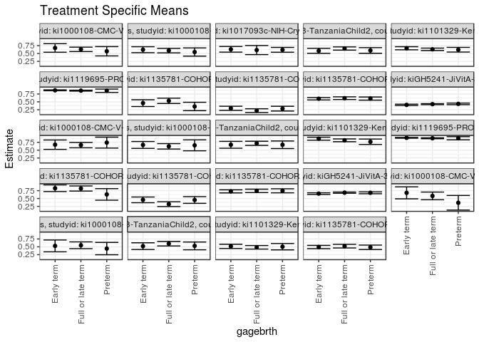

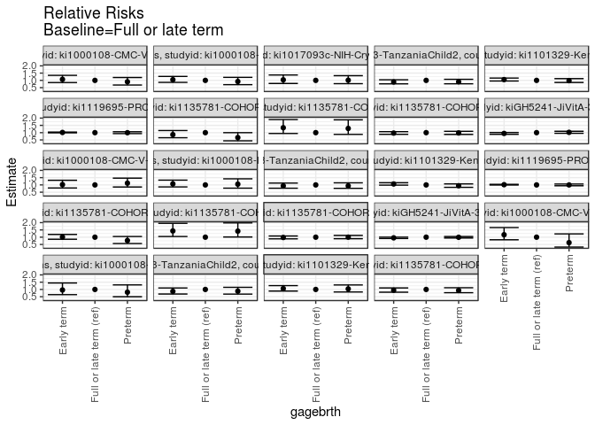

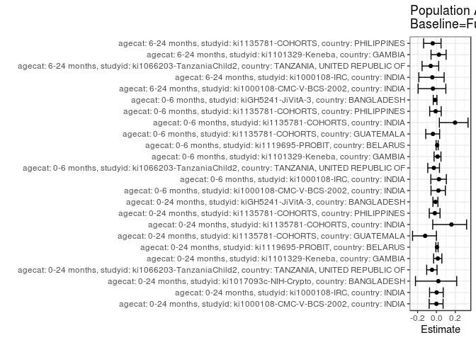

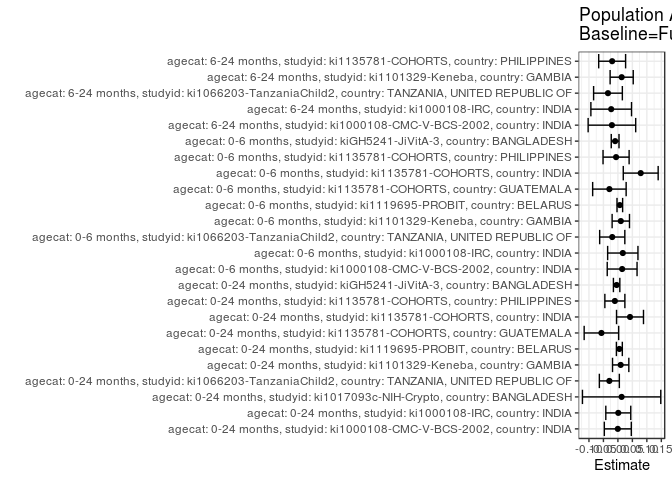

## Results Table

### Parameter: TSM

| agecat | studyid | country | intervention_level | baseline_level | estimate | ci_lower | ci_upper |
| --- | --- | --- | --- | --- | --- | --- | --- |
| 0-24 months | ki1000108-CMC-V-BCS-2002 | INDIA | Full or late term | NA | 0.6324324 | 0.5625487 | 0.7023162 |
| 0-24 months | ki1000108-CMC-V-BCS-2002 | INDIA | Preterm | NA | 0.5714286 | 0.4229572 | 0.7199000 |
| 0-24 months | ki1000108-CMC-V-BCS-2002 | INDIA | Early term | NA | 0.6769231 | 0.5408455 | 0.8130007 |
| 0-24 months | ki1000108-IRC | INDIA | Full or late term | NA | 0.5929204 | 0.5209401 | 0.6649006 |
| 0-24 months | ki1000108-IRC | INDIA | Preterm | NA | 0.5471698 | 0.4158117 | 0.6785279 |
| 0-24 months | ki1000108-IRC | INDIA | Early term | NA | 0.6213592 | 0.5268794 | 0.7158391 |
| 0-24 months | ki1017093c-NIH-Crypto | BANGLADESH | Full or late term | NA | 0.6097561 | 0.4654735 | 0.7540387 |
| 0-24 months | ki1017093c-NIH-Crypto | BANGLADESH | Preterm | NA | 0.6174497 | 0.5406130 | 0.6942863 |
| 0-24 months | ki1017093c-NIH-Crypto | BANGLADESH | Early term | NA | 0.6333333 | 0.5433479 | 0.7233188 |
| 0-24 months | ki1066203-TanzaniaChild2 | TANZANIA, UNITED REPUBLIC OF | Full or late term | NA | 0.6586667 | 0.6078603 | 0.7094731 |
| 0-24 months | ki1066203-TanzaniaChild2 | TANZANIA, UNITED REPUBLIC OF | Preterm | NA | 0.5968992 | 0.5064015 | 0.6873969 |
| 0-24 months | ki1066203-TanzaniaChild2 | TANZANIA, UNITED REPUBLIC OF | Early term | NA | 0.5864198 | 0.5062428 | 0.6665967 |
| 0-24 months | ki1101329-Keneba | GAMBIA | Full or late term | NA | 0.6333333 | 0.5941656 | 0.6725011 |
| 0-24 months | ki1101329-Keneba | GAMBIA | Preterm | NA | 0.6205128 | 0.5465714 | 0.6944543 |
| 0-24 months | ki1101329-Keneba | GAMBIA | Early term | NA | 0.6674528 | 0.6182486 | 0.7166571 |
| 0-24 months | ki1119695-PROBIT | BELARUS | Full or late term | NA | 0.8561644 | 0.8414854 | 0.8708434 |
| 0-24 months | ki1119695-PROBIT | BELARUS | Preterm | NA | 0.8527607 | 0.7997707 | 0.9057508 |
| 0-24 months | ki1119695-PROBIT | BELARUS | Early term | NA | 0.8671800 | 0.8527899 | 0.8815701 |
| 0-24 months | ki1135781-COHORTS | GUATEMALA | Full or late term | NA | 0.5319149 | 0.4468531 | 0.6169767 |
| 0-24 months | ki1135781-COHORTS | GUATEMALA | Preterm | NA | 0.3518519 | 0.2184275 | 0.4852762 |
| 0-24 months | ki1135781-COHORTS | GUATEMALA | Early term | NA | 0.4588235 | 0.3513175 | 0.5663296 |
| 0-24 months | ki1135781-COHORTS | INDIA | Full or late term | NA | 0.2200957 | 0.1607962 | 0.2793952 |
| 0-24 months | ki1135781-COHORTS | INDIA | Preterm | NA | 0.2835821 | 0.2080763 | 0.3590879 |
| 0-24 months | ki1135781-COHORTS | INDIA | Early term | NA | 0.2944444 | 0.2285314 | 0.3603575 |
| 0-24 months | ki1135781-COHORTS | PHILIPPINES | Full or late term | NA | 0.6164623 | 0.5734554 | 0.6594693 |
| 0-24 months | ki1135781-COHORTS | PHILIPPINES | Preterm | NA | 0.6040609 | 0.5540745 | 0.6540474 |
| 0-24 months | ki1135781-COHORTS | PHILIPPINES | Early term | NA | 0.5985915 | 0.5610039 | 0.6361792 |
| 0-24 months | kiGH5241-JiVitA-3 | BANGLADESH | Full or late term | NA | 0.4259459 | 0.4100490 | 0.4418429 |
| 0-24 months | kiGH5241-JiVitA-3 | BANGLADESH | Preterm | NA | 0.4349835 | 0.4098805 | 0.4600865 |
| 0-24 months | kiGH5241-JiVitA-3 | BANGLADESH | Early term | NA | 0.4030227 | 0.3814877 | 0.4245576 |
| 0-6 months | ki1000108-CMC-V-BCS-2002 | INDIA | Full or late term | NA | 0.6610169 | 0.5757140 | 0.7463199 |
| 0-6 months | ki1000108-CMC-V-BCS-2002 | INDIA | Preterm | NA | 0.7407407 | 0.5666423 | 0.9148392 |
| 0-6 months | ki1000108-CMC-V-BCS-2002 | INDIA | Early term | NA | 0.6750000 | 0.5258441 | 0.8241559 |
| 0-6 months | ki1000108-IRC | INDIA | Full or late term | NA | 0.6222222 | 0.5361698 | 0.7082747 |
| 0-6 months | ki1000108-IRC | INDIA | Preterm | NA | 0.6538462 | 0.4797295 | 0.8279628 |
| 0-6 months | ki1000108-IRC | INDIA | Early term | NA | 0.6666667 | 0.5568093 | 0.7765240 |
| 0-6 months | ki1066203-TanzaniaChild2 | TANZANIA, UNITED REPUBLIC OF | Full or late term | NA | 0.7189189 | 0.6530656 | 0.7847722 |
| 0-6 months | ki1066203-TanzaniaChild2 | TANZANIA, UNITED REPUBLIC OF | Preterm | NA | 0.6721311 | 0.5518529 | 0.7924094 |
| 0-6 months | ki1066203-TanzaniaChild2 | TANZANIA, UNITED REPUBLIC OF | Early term | NA | 0.6714286 | 0.5614299 | 0.7814273 |
| 0-6 months | ki1101329-Keneba | GAMBIA | Full or late term | NA | 0.8133803 | 0.7695675 | 0.8571931 |
| 0-6 months | ki1101329-Keneba | GAMBIA | Preterm | NA | 0.7674419 | 0.6814375 | 0.8534462 |
| 0-6 months | ki1101329-Keneba | GAMBIA | Early term | NA | 0.8648649 | 0.8169793 | 0.9127504 |
| 0-6 months | ki1119695-PROBIT | BELARUS | Full or late term | NA | 0.8789026 | 0.8648824 | 0.8929227 |
| 0-6 months | ki1119695-PROBIT | BELARUS | Preterm | NA | 0.8789809 | 0.8284410 | 0.9295208 |
| 0-6 months | ki1119695-PROBIT | BELARUS | Early term | NA | 0.8930723 | 0.8793931 | 0.9067515 |
| 0-6 months | ki1135781-COHORTS | GUATEMALA | Full or late term | NA | 0.8181818 | 0.7368393 | 0.8995243 |
| 0-6 months | ki1135781-COHORTS | GUATEMALA | Preterm | NA | 0.6296296 | 0.4457667 | 0.8134926 |
| 0-6 months | ki1135781-COHORTS | GUATEMALA | Early term | NA | 0.8260870 | 0.7207224 | 0.9314515 |
| 0-6 months | ki1135781-COHORTS | INDIA | Full or late term | NA | 0.3194444 | 0.2431789 | 0.3957100 |
| 0-6 months | ki1135781-COHORTS | INDIA | Preterm | NA | 0.4523810 | 0.3457871 | 0.5589748 |
| 0-6 months | ki1135781-COHORTS | INDIA | Early term | NA | 0.4568966 | 0.3661142 | 0.5476789 |
| 0-6 months | ki1135781-COHORTS | PHILIPPINES | Full or late term | NA | 0.7428571 | 0.6882172 | 0.7974970 |
| 0-6 months | ki1135781-COHORTS | PHILIPPINES | Preterm | NA | 0.7444444 | 0.6801122 | 0.8087766 |
| 0-6 months | ki1135781-COHORTS | PHILIPPINES | Early term | NA | 0.7272727 | 0.6781705 | 0.7763749 |
| 0-6 months | kiGH5241-JiVitA-3 | BANGLADESH | Full or late term | NA | 0.6864111 | 0.6674335 | 0.7053888 |
| 0-6 months | kiGH5241-JiVitA-3 | BANGLADESH | Preterm | NA | 0.6814891 | 0.6521453 | 0.7108330 |
| 0-6 months | kiGH5241-JiVitA-3 | BANGLADESH | Early term | NA | 0.6552007 | 0.6285258 | 0.6818756 |
| 6-24 months | ki1000108-CMC-V-BCS-2002 | INDIA | Full or late term | NA | 0.5820896 | 0.4594727 | 0.7047064 |
| 6-24 months | ki1000108-CMC-V-BCS-2002 | INDIA | Preterm | NA | 0.3636364 | 0.1308138 | 0.5964590 |
| 6-24 months | ki1000108-CMC-V-BCS-2002 | INDIA | Early term | NA | 0.6800000 | 0.4890151 | 0.8709849 |
| 6-24 months | ki1000108-IRC | INDIA | Full or late term | NA | 0.5494505 | 0.4419865 | 0.6569146 |
| 6-24 months | ki1000108-IRC | INDIA | Preterm | NA | 0.4444444 | 0.2479491 | 0.6409398 |
| 6-24 months | ki1000108-IRC | INDIA | Early term | NA | 0.5294118 | 0.3414334 | 0.7173901 |
| 6-24 months | ki1066203-TanzaniaChild2 | TANZANIA, UNITED REPUBLIC OF | Full or late term | NA | 0.6000000 | 0.5285487 | 0.6714513 |
| 6-24 months | ki1066203-TanzaniaChild2 | TANZANIA, UNITED REPUBLIC OF | Preterm | NA | 0.5294118 | 0.4055054 | 0.6533181 |
| 6-24 months | ki1066203-TanzaniaChild2 | TANZANIA, UNITED REPUBLIC OF | Early term | NA | 0.5217391 | 0.4145563 | 0.6289220 |
| 6-24 months | ki1101329-Keneba | GAMBIA | Full or late term | NA | 0.4855491 | 0.4289230 | 0.5421753 |
| 6-24 months | ki1101329-Keneba | GAMBIA | Preterm | NA | 0.5045872 | 0.4038057 | 0.6053686 |
| 6-24 months | ki1101329-Keneba | GAMBIA | Early term | NA | 0.5146444 | 0.4472547 | 0.5820340 |
| 6-24 months | ki1135781-COHORTS | PHILIPPINES | Full or late term | NA | 0.5214724 | 0.4634910 | 0.5794538 |
| 6-24 months | ki1135781-COHORTS | PHILIPPINES | Preterm | NA | 0.4859813 | 0.4159761 | 0.5559865 |
| 6-24 months | ki1135781-COHORTS | PHILIPPINES | Early term | NA | 0.4936061 | 0.4414105 | 0.5458018 |

### Parameter: E(Y)

| agecat | studyid | country | intervention_level | baseline_level | estimate | ci_lower | ci_upper |
| --- | --- | --- | --- | --- | --- | --- | --- |
| 0-24 months | ki1000108-CMC-V-BCS-2002 | INDIA | NA | NA | 0.6321070 | 0.5744109 | 0.6898031 |
| 0-24 months | ki1000108-IRC | INDIA | NA | NA | 0.5942408 | 0.5412823 | 0.6471994 |
| 0-24 months | ki1017093c-NIH-Crypto | BANGLADESH | NA | NA | 0.6225806 | 0.5684562 | 0.6767051 |
| 0-24 months | ki1066203-TanzaniaChild2 | TANZANIA, UNITED REPUBLIC OF | NA | NA | 0.6291291 | 0.5901846 | 0.6680736 |
| 0-24 months | ki1101329-Keneba | GAMBIA | NA | NA | 0.6429143 | 0.6145621 | 0.6712666 |
| 0-24 months | ki1119695-PROBIT | BELARUS | NA | NA | 0.8612051 | 0.8511051 | 0.8713052 |
| 0-24 months | ki1135781-COHORTS | GUATEMALA | NA | NA | 0.4750000 | 0.4147665 | 0.5352335 |
| 0-24 months | ki1135781-COHORTS | INDIA | NA | NA | 0.2619503 | 0.2237649 | 0.3001357 |
| 0-24 months | ki1135781-COHORTS | PHILIPPINES | NA | NA | 0.6059701 | 0.5813402 | 0.6306001 |
| 0-24 months | kiGH5241-JiVitA-3 | BANGLADESH | NA | NA | 0.4215278 | 0.4101272 | 0.4329284 |
| 0-6 months | ki1000108-CMC-V-BCS-2002 | INDIA | NA | NA | 0.6756757 | 0.6074152 | 0.7439361 |
| 0-6 months | ki1000108-IRC | INDIA | NA | NA | 0.6391304 | 0.5756367 | 0.7026242 |
| 0-6 months | ki1066203-TanzaniaChild2 | TANZANIA, UNITED REPUBLIC OF | NA | NA | 0.6993671 | 0.6481378 | 0.7505964 |
| 0-6 months | ki1101329-Keneba | GAMBIA | NA | NA | 0.8234234 | 0.7927195 | 0.8541273 |
| 0-6 months | ki1119695-PROBIT | BELARUS | NA | NA | 0.8855266 | 0.8758983 | 0.8951550 |
| 0-6 months | ki1135781-COHORTS | GUATEMALA | NA | NA | 0.7888199 | 0.7258783 | 0.8517615 |
| 0-6 months | ki1135781-COHORTS | INDIA | NA | NA | 0.3982558 | 0.3464489 | 0.4500628 |
| 0-6 months | ki1135781-COHORTS | PHILIPPINES | NA | NA | 0.7365591 | 0.7047881 | 0.7683302 |
| 0-6 months | kiGH5241-JiVitA-3 | BANGLADESH | NA | NA | 0.6768510 | 0.6631621 | 0.6905400 |
| 6-24 months | ki1000108-CMC-V-BCS-2002 | INDIA | NA | NA | 0.5614035 | 0.4645960 | 0.6582110 |
| 6-24 months | ki1000108-IRC | INDIA | NA | NA | 0.5263158 | 0.4415211 | 0.6111105 |
| 6-24 months | ki1066203-TanzaniaChild2 | TANZANIA, UNITED REPUBLIC OF | NA | NA | 0.5657143 | 0.5118874 | 0.6195411 |
| 6-24 months | ki1101329-Keneba | GAMBIA | NA | NA | 0.4985591 | 0.4587425 | 0.5383757 |
| 6-24 months | ki1135781-COHORTS | PHILIPPINES | NA | NA | 0.5016112 | 0.4676556 | 0.5355667 |

### Parameter: RR

| agecat | studyid | country | intervention_level | baseline_level | estimate | ci_lower | ci_upper |
| --- | --- | --- | --- | --- | --- | --- | --- |
| 0-24 months | ki1000108-CMC-V-BCS-2002 | INDIA | Full or late term | Full or late term | 1.0000000 | 1.0000000 | 1.0000000 |
| 0-24 months | ki1000108-CMC-V-BCS-2002 | INDIA | Preterm | Full or late term | 0.9035409 | 0.6811817 | 1.1984852 |
| 0-24 months | ki1000108-CMC-V-BCS-2002 | INDIA | Early term | Full or late term | 1.0703485 | 0.8509967 | 1.3462401 |
| 0-24 months | ki1000108-IRC | INDIA | Full or late term | Full or late term | 1.0000000 | 1.0000000 | 1.0000000 |
| 0-24 months | ki1000108-IRC | INDIA | Preterm | Full or late term | 0.9228386 | 0.7051713 | 1.2076940 |
| 0-24 months | ki1000108-IRC | INDIA | Early term | Full or late term | 1.0479641 | 0.8626426 | 1.2730981 |
| 0-24 months | ki1017093c-NIH-Crypto | BANGLADESH | Full or late term | Full or late term | 1.0000000 | 1.0000000 | 1.0000000 |
| 0-24 months | ki1017093c-NIH-Crypto | BANGLADESH | Preterm | Full or late term | 1.0126174 | 0.7749201 | 1.3232255 |
| 0-24 months | ki1017093c-NIH-Crypto | BANGLADESH | Early term | Full or late term | 1.0386667 | 0.7878903 | 1.3692622 |
| 0-24 months | ki1066203-TanzaniaChild2 | TANZANIA, UNITED REPUBLIC OF | Full or late term | Full or late term | 1.0000000 | 1.0000000 | 1.0000000 |
| 0-24 months | ki1066203-TanzaniaChild2 | TANZANIA, UNITED REPUBLIC OF | Preterm | Full or late term | 0.9062235 | 0.7644676 | 1.0742653 |
| 0-24 months | ki1066203-TanzaniaChild2 | TANZANIA, UNITED REPUBLIC OF | Early term | Full or late term | 0.8903134 | 0.7609661 | 1.0416468 |
| 0-24 months | ki1101329-Keneba | GAMBIA | Full or late term | Full or late term | 1.0000000 | 1.0000000 | 1.0000000 |
| 0-24 months | ki1101329-Keneba | GAMBIA | Preterm | Full or late term | 0.9797571 | 0.8566605 | 1.1205418 |
| 0-24 months | ki1101329-Keneba | GAMBIA | Early term | Full or late term | 1.0538729 | 0.9571635 | 1.1603536 |
| 0-24 months | ki1119695-PROBIT | BELARUS | Full or late term | Full or late term | 1.0000000 | 1.0000000 | 1.0000000 |
| 0-24 months | ki1119695-PROBIT | BELARUS | Preterm | Full or late term | 0.9960245 | 0.9338449 | 1.0623443 |
| 0-24 months | ki1119695-PROBIT | BELARUS | Early term | Full or late term | 1.0128662 | 0.9889844 | 1.0373247 |
| 0-24 months | ki1135781-COHORTS | GUATEMALA | Full or late term | Full or late term | 1.0000000 | 1.0000000 | 1.0000000 |
| 0-24 months | ki1135781-COHORTS | GUATEMALA | Preterm | Full or late term | 0.6614815 | 0.4382920 | 0.9983248 |
| 0-24 months | ki1135781-COHORTS | GUATEMALA | Early term | Full or late term | 0.8625882 | 0.6494952 | 1.1455950 |
| 0-24 months | ki1135781-COHORTS | INDIA | Full or late term | Full or late term | 1.0000000 | 1.0000000 | 1.0000000 |
| 0-24 months | ki1135781-COHORTS | INDIA | Preterm | Full or late term | 1.2884491 | 0.8821822 | 1.8818118 |
| 0-24 months | ki1135781-COHORTS | INDIA | Early term | Full or late term | 1.3378019 | 0.9424712 | 1.8989589 |
| 0-24 months | ki1135781-COHORTS | PHILIPPINES | Full or late term | Full or late term | 1.0000000 | 1.0000000 | 1.0000000 |
| 0-24 months | ki1135781-COHORTS | PHILIPPINES | Preterm | Full or late term | 0.9798829 | 0.8793557 | 1.0919023 |
| 0-24 months | ki1135781-COHORTS | PHILIPPINES | Early term | Full or late term | 0.9710107 | 0.8840063 | 1.0665782 |
| 0-24 months | kiGH5241-JiVitA-3 | BANGLADESH | Full or late term | Full or late term | 1.0000000 | 1.0000000 | 1.0000000 |
| 0-24 months | kiGH5241-JiVitA-3 | BANGLADESH | Preterm | Full or late term | 1.0212176 | 0.9533901 | 1.0938706 |
| 0-24 months | kiGH5241-JiVitA-3 | BANGLADESH | Early term | Full or late term | 0.9461827 | 0.8864799 | 1.0099063 |
| 0-6 months | ki1000108-CMC-V-BCS-2002 | INDIA | Full or late term | Full or late term | 1.0000000 | 1.0000000 | 1.0000000 |
| 0-6 months | ki1000108-CMC-V-BCS-2002 | INDIA | Preterm | Full or late term | 1.1206078 | 0.8570471 | 1.4652192 |
| 0-6 months | ki1000108-CMC-V-BCS-2002 | INDIA | Early term | Full or late term | 1.0211538 | 0.7906029 | 1.3189367 |
| 0-6 months | ki1000108-IRC | INDIA | Full or late term | Full or late term | 1.0000000 | 1.0000000 | 1.0000000 |
| 0-6 months | ki1000108-IRC | INDIA | Preterm | Full or late term | 1.0508242 | 0.7784047 | 1.4185827 |
| 0-6 months | ki1000108-IRC | INDIA | Early term | Full or late term | 1.0714286 | 0.8640328 | 1.3286061 |
| 0-6 months | ki1066203-TanzaniaChild2 | TANZANIA, UNITED REPUBLIC OF | Full or late term | Full or late term | 1.0000000 | 1.0000000 | 1.0000000 |
| 0-6 months | ki1066203-TanzaniaChild2 | TANZANIA, UNITED REPUBLIC OF | Preterm | Full or late term | 0.9349193 | 0.7646574 | 1.1430923 |
| 0-6 months | ki1066203-TanzaniaChild2 | TANZANIA, UNITED REPUBLIC OF | Early term | Full or late term | 0.9339420 | 0.7741110 | 1.1267734 |
| 0-6 months | ki1101329-Keneba | GAMBIA | Full or late term | Full or late term | 1.0000000 | 1.0000000 | 1.0000000 |
| 0-6 months | ki1101329-Keneba | GAMBIA | Preterm | Full or late term | 0.9435216 | 0.8331966 | 1.0684548 |
| 0-6 months | ki1101329-Keneba | GAMBIA | Early term | Full or late term | 1.0632971 | 0.9842398 | 1.1487045 |
| 0-6 months | ki1119695-PROBIT | BELARUS | Full or late term | Full or late term | 1.0000000 | 1.0000000 | 1.0000000 |
| 0-6 months | ki1119695-PROBIT | BELARUS | Preterm | Full or late term | 1.0000891 | 0.9421593 | 1.0615809 |
| 0-6 months | ki1119695-PROBIT | BELARUS | Early term | Full or late term | 1.0161221 | 0.9938971 | 1.0388440 |
| 0-6 months | ki1135781-COHORTS | GUATEMALA | Full or late term | Full or late term | 1.0000000 | 1.0000000 | 1.0000000 |
| 0-6 months | ki1135781-COHORTS | GUATEMALA | Preterm | Full or late term | 0.7695473 | 0.5652821 | 1.0476239 |
| 0-6 months | ki1135781-COHORTS | GUATEMALA | Early term | Full or late term | 1.0096618 | 0.8589016 | 1.1868846 |
| 0-6 months | ki1135781-COHORTS | INDIA | Full or late term | Full or late term | 1.0000000 | 1.0000000 | 1.0000000 |
| 0-6 months | ki1135781-COHORTS | INDIA | Preterm | Full or late term | 1.4161491 | 1.0125803 | 1.9805622 |
| 0-6 months | ki1135781-COHORTS | INDIA | Early term | Full or late term | 1.4302849 | 1.0483994 | 1.9512743 |
| 0-6 months | ki1135781-COHORTS | PHILIPPINES | Full or late term | Full or late term | 1.0000000 | 1.0000000 | 1.0000000 |
| 0-6 months | ki1135781-COHORTS | PHILIPPINES | Preterm | Full or late term | 1.0021368 | 0.8946287 | 1.1225642 |
| 0-6 months | ki1135781-COHORTS | PHILIPPINES | Early term | Full or late term | 0.9790210 | 0.8859946 | 1.0818148 |
| 0-6 months | kiGH5241-JiVitA-3 | BANGLADESH | Full or late term | Full or late term | 1.0000000 | 1.0000000 | 1.0000000 |
| 0-6 months | kiGH5241-JiVitA-3 | BANGLADESH | Preterm | Full or late term | 0.9928294 | 0.9433038 | 1.0449551 |
| 0-6 months | kiGH5241-JiVitA-3 | BANGLADESH | Early term | Full or late term | 0.9545309 | 0.9086929 | 1.0026812 |
| 6-24 months | ki1000108-CMC-V-BCS-2002 | INDIA | Full or late term | Full or late term | 1.0000000 | 1.0000000 | 1.0000000 |
| 6-24 months | ki1000108-CMC-V-BCS-2002 | INDIA | Preterm | Full or late term | 0.6247086 | 0.3184160 | 1.2256319 |
| 6-24 months | ki1000108-CMC-V-BCS-2002 | INDIA | Early term | Full or late term | 1.1682051 | 0.8223605 | 1.6594951 |
| 6-24 months | ki1000108-IRC | INDIA | Full or late term | Full or late term | 1.0000000 | 1.0000000 | 1.0000000 |
| 6-24 months | ki1000108-IRC | INDIA | Preterm | Full or late term | 0.8088889 | 0.4987649 | 1.3118429 |
| 6-24 months | ki1000108-IRC | INDIA | Early term | Full or late term | 0.9635294 | 0.6423669 | 1.4452627 |
| 6-24 months | ki1066203-TanzaniaChild2 | TANZANIA, UNITED REPUBLIC OF | Full or late term | Full or late term | 1.0000000 | 1.0000000 | 1.0000000 |
| 6-24 months | ki1066203-TanzaniaChild2 | TANZANIA, UNITED REPUBLIC OF | Preterm | Full or late term | 0.8823529 | 0.6785706 | 1.1473334 |
| 6-24 months | ki1066203-TanzaniaChild2 | TANZANIA, UNITED REPUBLIC OF | Early term | Full or late term | 0.8695652 | 0.6857587 | 1.1026381 |
| 6-24 months | ki1101329-Keneba | GAMBIA | Full or late term | Full or late term | 1.0000000 | 1.0000000 | 1.0000000 |
| 6-24 months | ki1101329-Keneba | GAMBIA | Preterm | Full or late term | 1.0392093 | 0.8245529 | 1.3097472 |
| 6-24 months | ki1101329-Keneba | GAMBIA | Early term | Full or late term | 1.0599223 | 0.8894035 | 1.2631334 |
| 6-24 months | ki1135781-COHORTS | PHILIPPINES | Full or late term | Full or late term | 1.0000000 | 1.0000000 | 1.0000000 |
| 6-24 months | ki1135781-COHORTS | PHILIPPINES | Preterm | Full or late term | 0.9319406 | 0.7768892 | 1.1179372 |
| 6-24 months | ki1135781-COHORTS | PHILIPPINES | Early term | Full or late term | 0.9465624 | 0.8119141 | 1.1035408 |

### Parameter: PAR

| agecat | studyid | country | intervention_level | baseline_level | estimate | ci_lower | ci_upper |
| --- | --- | --- | --- | --- | --- | --- | --- |
| 0-24 months | ki1000108-CMC-V-BCS-2002 | INDIA | Full or late term | NA | -0.0003254 | -0.0469263 | 0.0462755 |
| 0-24 months | ki1000108-IRC | INDIA | Full or late term | NA | 0.0013205 | -0.0417711 | 0.0444121 |
| 0-24 months | ki1017093c-NIH-Crypto | BANGLADESH | Full or late term | NA | 0.0128245 | -0.1224587 | 0.1481078 |
| 0-24 months | ki1066203-TanzaniaChild2 | TANZANIA, UNITED REPUBLIC OF | Full or late term | NA | -0.0295375 | -0.0640612 | 0.0049861 |
| 0-24 months | ki1101329-Keneba | GAMBIA | Full or late term | NA | 0.0095810 | -0.0185740 | 0.0377360 |
| 0-24 months | ki1119695-PROBIT | BELARUS | Full or late term | NA | 0.0050408 | -0.0051826 | 0.0152641 |
| 0-24 months | ki1135781-COHORTS | GUATEMALA | Full or late term | NA | -0.0569149 | -0.1165335 | 0.0027037 |
| 0-24 months | ki1135781-COHORTS | INDIA | Full or late term | NA | 0.0418546 | -0.0046947 | 0.0884039 |
| 0-24 months | ki1135781-COHORTS | PHILIPPINES | Full or late term | NA | -0.0104922 | -0.0450644 | 0.0240800 |
| 0-24 months | kiGH5241-JiVitA-3 | BANGLADESH | Full or late term | NA | -0.0044182 | -0.0155071 | 0.0066708 |
| 0-6 months | ki1000108-CMC-V-BCS-2002 | INDIA | Full or late term | NA | 0.0146587 | -0.0368417 | 0.0661592 |
| 0-6 months | ki1000108-IRC | INDIA | Full or late term | NA | 0.0169082 | -0.0354403 | 0.0692567 |
| 0-6 months | ki1066203-TanzaniaChild2 | TANZANIA, UNITED REPUBLIC OF | Full or late term | NA | -0.0195518 | -0.0629854 | 0.0238817 |
| 0-6 months | ki1101329-Keneba | GAMBIA | Full or late term | NA | 0.0100431 | -0.0199573 | 0.0400436 |
| 0-6 months | ki1119695-PROBIT | BELARUS | Full or late term | NA | 0.0066241 | -0.0030871 | 0.0163352 |
| 0-6 months | ki1135781-COHORTS | GUATEMALA | Full or late term | NA | -0.0293619 | -0.0871996 | 0.0284757 |
| 0-6 months | ki1135781-COHORTS | INDIA | Full or late term | NA | 0.0788114 | 0.0185551 | 0.1390677 |
| 0-6 months | ki1135781-COHORTS | PHILIPPINES | Full or late term | NA | -0.0062980 | -0.0513388 | 0.0387428 |
| 0-6 months | kiGH5241-JiVitA-3 | BANGLADESH | Full or late term | NA | -0.0095601 | -0.0229284 | 0.0038082 |
| 6-24 months | ki1000108-CMC-V-BCS-2002 | INDIA | Full or late term | NA | -0.0206860 | -0.1028182 | 0.0614461 |
| 6-24 months | ki1000108-IRC | INDIA | Full or late term | NA | -0.0231348 | -0.0933454 | 0.0470759 |
| 6-24 months | ki1066203-TanzaniaChild2 | TANZANIA, UNITED REPUBLIC OF | Full or late term | NA | -0.0342857 | -0.0839393 | 0.0153678 |
| 6-24 months | ki1101329-Keneba | GAMBIA | Full or late term | NA | 0.0130099 | -0.0269173 | 0.0529372 |
| 6-24 months | ki1135781-COHORTS | PHILIPPINES | Full or late term | NA | -0.0198612 | -0.0663470 | 0.0266245 |

### Parameter: PAF

| agecat | studyid | country | intervention_level | baseline_level | estimate | ci_lower | ci_upper |
| --- | --- | --- | --- | --- | --- | --- | --- |
| 0-24 months | ki1000108-CMC-V-BCS-2002 | INDIA | Full or late term | NA | -0.0005148 | -0.0770278 | 0.0705627 |
| 0-24 months | ki1000108-IRC | INDIA | Full or late term | NA | 0.0022221 | -0.0730179 | 0.0721863 |
| 0-24 months | ki1017093c-NIH-Crypto | BANGLADESH | Full or late term | NA | 0.0205990 | -0.2226324 | 0.2154418 |
| 0-24 months | ki1066203-TanzaniaChild2 | TANZANIA, UNITED REPUBLIC OF | Full or late term | NA | -0.0469499 | -0.1035144 | 0.0067152 |
| 0-24 months | ki1101329-Keneba | GAMBIA | Full or late term | NA | 0.0149024 | -0.0298566 | 0.0577162 |
| 0-24 months | ki1119695-PROBIT | BELARUS | Full or late term | NA | 0.0058531 | -0.0060922 | 0.0176566 |
| 0-24 months | ki1135781-COHORTS | GUATEMALA | Full or late term | NA | -0.1198208 | -0.2535385 | -0.0003671 |
| 0-24 months | ki1135781-COHORTS | INDIA | Full or late term | NA | 0.1597807 | -0.0391173 | 0.3206075 |
| 0-24 months | ki1135781-COHORTS | PHILIPPINES | Full or late term | NA | -0.0173147 | -0.0759812 | 0.0381531 |
| 0-24 months | kiGH5241-JiVitA-3 | BANGLADESH | Full or late term | NA | -0.0104813 | -0.0371351 | 0.0154875 |
| 0-6 months | ki1000108-CMC-V-BCS-2002 | INDIA | Full or late term | NA | 0.0216949 | -0.0575958 | 0.0950410 |
| 0-6 months | ki1000108-IRC | INDIA | Full or late term | NA | 0.0264550 | -0.0593125 | 0.1052784 |
| 0-6 months | ki1066203-TanzaniaChild2 | TANZANIA, UNITED REPUBLIC OF | Full or late term | NA | -0.0279565 | -0.0920958 | 0.0324160 |
| 0-6 months | ki1101329-Keneba | GAMBIA | Full or late term | NA | 0.0121968 | -0.0249398 | 0.0479879 |
| 0-6 months | ki1119695-PROBIT | BELARUS | Full or late term | NA | 0.0074804 | -0.0035515 | 0.0183909 |
| 0-6 months | ki1135781-COHORTS | GUATEMALA | Full or late term | NA | -0.0372226 | -0.1135640 | 0.0338851 |
| 0-6 months | ki1135781-COHORTS | INDIA | Full or late term | NA | 0.1978913 | 0.0312167 | 0.3358904 |
| 0-6 months | ki1135781-COHORTS | PHILIPPINES | Full or late term | NA | -0.0085506 | -0.0716011 | 0.0507902 |
| 0-6 months | kiGH5241-JiVitA-3 | BANGLADESH | Full or late term | NA | -0.0141244 | -0.0340756 | 0.0054418 |
| 6-24 months | ki1000108-CMC-V-BCS-2002 | INDIA | Full or late term | NA | -0.0368470 | -0.1946251 | 0.1000928 |
| 6-24 months | ki1000108-IRC | INDIA | Full or late term | NA | -0.0439560 | -0.1868530 | 0.0817361 |
| 6-24 months | ki1066203-TanzaniaChild2 | TANZANIA, UNITED REPUBLIC OF | Full or late term | NA | -0.0606061 | -0.1526179 | 0.0240606 |
| 6-24 months | ki1101329-Keneba | GAMBIA | Full or late term | NA | 0.0260951 | -0.0574238 | 0.1030174 |
| 6-24 months | ki1135781-COHORTS | PHILIPPINES | Full or late term | NA | -0.0395949 | -0.1365217 | 0.0490657 |